# project 4

Qiang

2016年7月6日

# quality of white wines exploration by Xia

- dataset Overview :

  This data set contains 4,898 white wines with 11 variables on quantifying the chemical properties of each wine. At least 3 wine experts rated the quality of each wine, providing a rating between 0 (very bad) and 10 (very excellent).
- I want to know:

  Which chemical properties influence the quality of white wines?

  May I predict quality rating through some chemical properties?
- Things I will do

  look data distribution in these 11 variables

  make correlation matrix to pick up some varibale with relative larger correlation

  figure out how these variables influence quality

  build a model that may predict quality by these variables

## 1 data distribution

```
## 'data.frame':    4898 obs. of  13 variables:
##  $ X                   : int  1 2 3 4 5 6 7 8 9 10 ...
##  $ fixed.acidity       : num  7 6.3 8.1 7.2 7.2 8.1 6.2 7 6.3 8.1 ...
##  $ volatile.acidity    : num  0.27 0.3 0.28 0.23 0.23 0.28 0.32 0.27 0.3 0.22 ...
##  $ citric.acid         : num  0.36 0.34 0.4 0.32 0.32 0.4 0.16 0.36 0.34 0.43 ...
##  $ residual.sugar      : num  20.7 1.6 6.9 8.5 8.5 6.9 7 20.7 1.6 1.5 ...
##  $ chlorides           : num  0.045 0.049 0.05 0.058 0.058 0.05 0.045 0.045 0.049 0.044 ...
##  $ free.sulfur.dioxide : num  45 14 30 47 47 30 30 45 14 28 ...
##  $ total.sulfur.dioxide: num  170 132 97 186 186 97 136 170 132 129 ...
##  $ density             : num  1.001 0.994 0.995 0.996 0.996 ...
##  $ pH                  : num  3 3.3 3.26 3.19 3.19 3.26 3.18 3 3.3 3.22 ...
##  $ sulphates           : num  0.45 0.49 0.44 0.4 0.4 0.44 0.47 0.45 0.49 0.45 ...
##  $ alcohol             : num  8.8 9.5 10.1 9.9 9.9 10.1 9.6 8.8 9.5 11 ...
##  $ quality             : int  6 6 6 6 6 6 6 6 6 6 ...
```

```
##  [1] "X"                    "fixed.acidity"        "volatile.acidity"
##  [4] "citric.acid"          "residual.sugar"       "chlorides"
##  [7] "free.sulfur.dioxide"  "total.sulfur.dioxide" "density"
## [10] "pH"                   "sulphates"            "alcohol"
## [13] "quality"
```

### quality

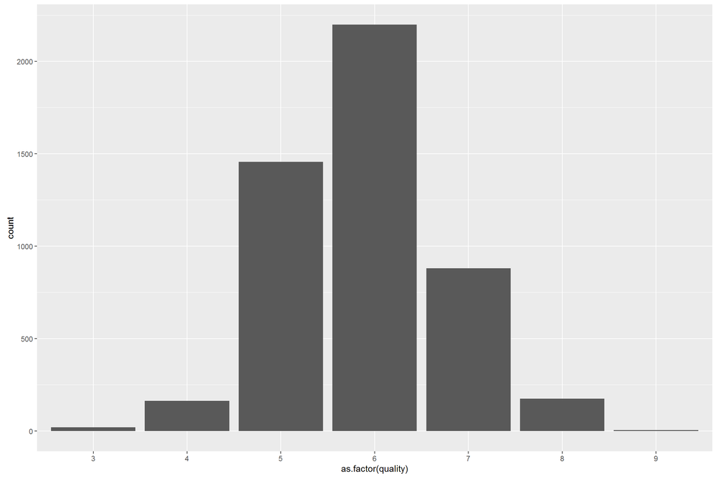

```
##
##    3    4    5    6    7    8    9
##   20  163 1457 2198  880  175    5
```

most wines quality was between 5 and 7

### volatile.acidity

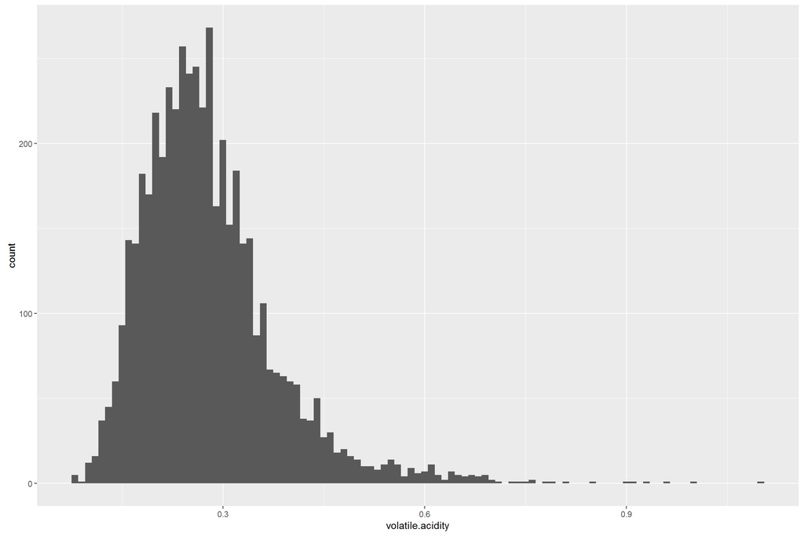

```
##    Min. 1st Qu.  Median    Mean 3rd Qu.    Max.
##  0.0800  0.2100  0.2600  0.2782  0.3200  1.1000
```

distribution of volatile.acidity is slightly right skew most wines’ volatile acidity content are between 0.21 and 0.32, median 0.26 and mean 0.2782 . and there some outliers that have high content of volatile acidity

### free.sulfur.dioxide

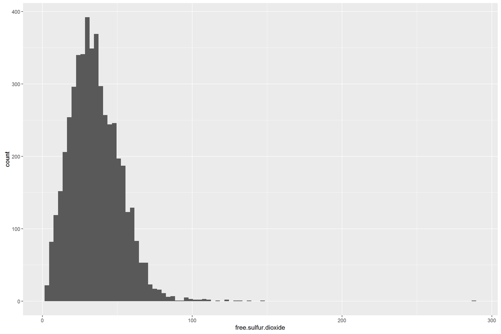

```
##    Min. 1st Qu.  Median    Mean 3rd Qu.    Max.
##    2.00   23.00   34.00   35.31   46.00  289.00
```

most wines’ free.sulfur.dioxide content are between 20 and 50 , median 34 and mean 35.31 ,there are and there some outliers that have high content of free sulfur dioxide. so let’s zoom in

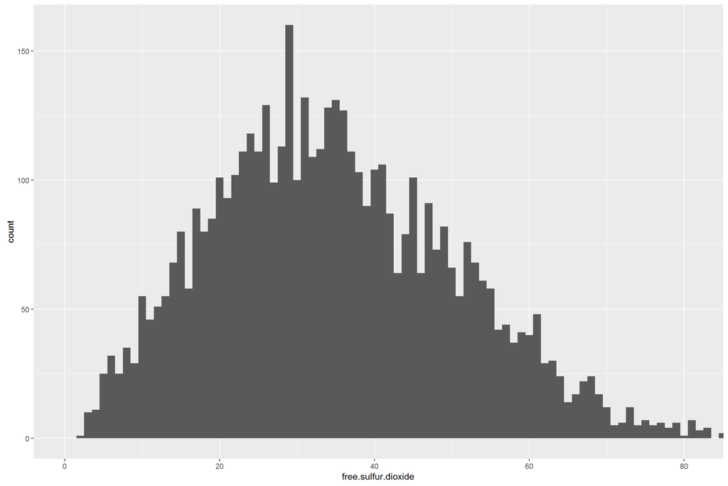

the distribution of wines in free.sulfur.dioxide was mainly symmetry

### citric.acid

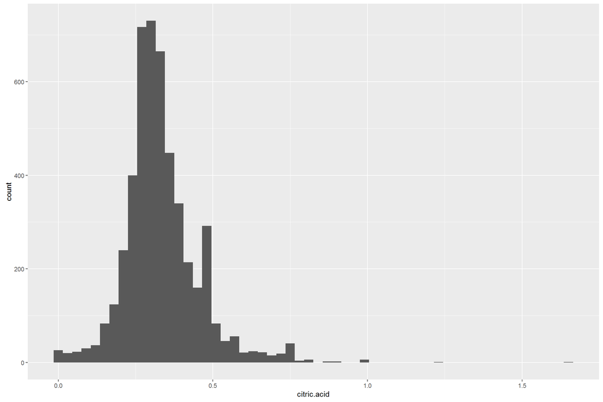

```
##    Min. 1st Qu.  Median    Mean 3rd Qu.    Max.
##  0.0000  0.2700  0.3200  0.3342  0.3900  1.6600
```

the distribution of wine in citric.acid was almostly symmetry . most wines have citric acid between 0.25 and 0.4, and there some higher outliers.

### residual.sugar

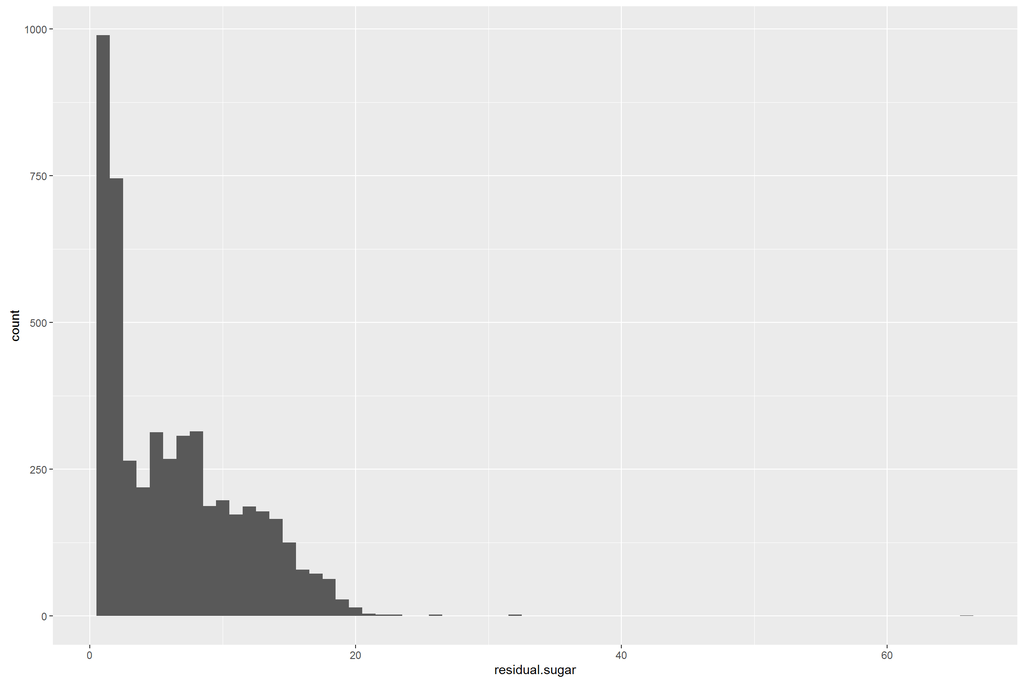

```
##    Min. 1st Qu.  Median    Mean 3rd Qu.    Max.
##   0.600   1.700   5.200   6.391   9.900  65.800
```

the distribution of wine in residual.sugar was right skew. most wines’ residual sugar are lower than 6,mean is 6,391, median is 5.2. and there some outliers even higer than 20 .

### chlorides

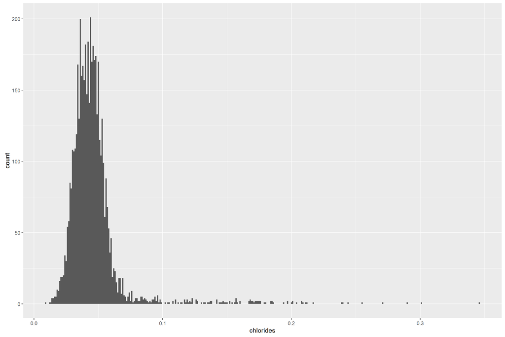

```
##    Min. 1st Qu.  Median    Mean 3rd Qu.    Max.
## 0.00900 0.03600 0.04300 0.04577 0.05000 0.34600
```

most wines’ chlorides contents are between 0.03 and 0.06 , mean 0.04577, median 0.043 and there are some higher content outlier

let’s zoom in

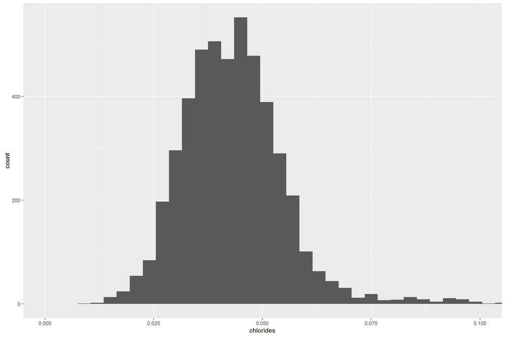

the distribution of wine in chlorides was symmetry.

### total.sulfur.dioxide

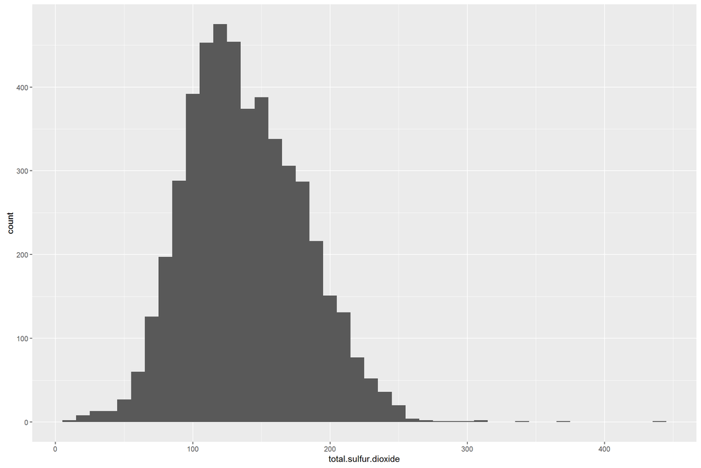

```
##    Min. 1st Qu.  Median    Mean 3rd Qu.    Max.
##     9.0   108.0   134.0   138.4   167.0   440.0
```

the distribution of wine in total.sulfur.dioxidechlorides was symmetry. most wines’ total sulfur.dioxide contents are between 100 and 180 , mean is 138.4, median is 134

### density

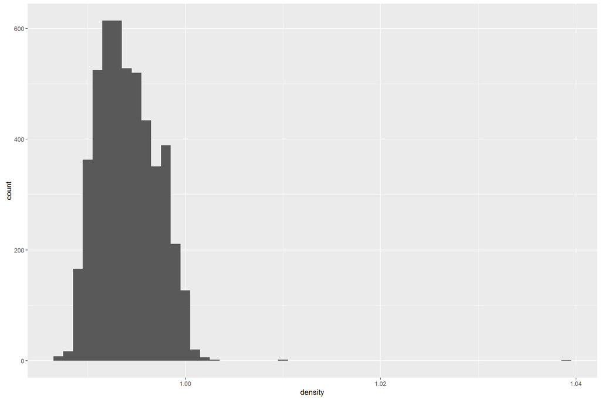

```
##    Min. 1st Qu.  Median    Mean 3rd Qu.    Max.
##  0.9871  0.9917  0.9937  0.9940  0.9961  1.0390
```

the distribution of wine in density was symmetry , most density are between 0.98 and 1.00

### pH

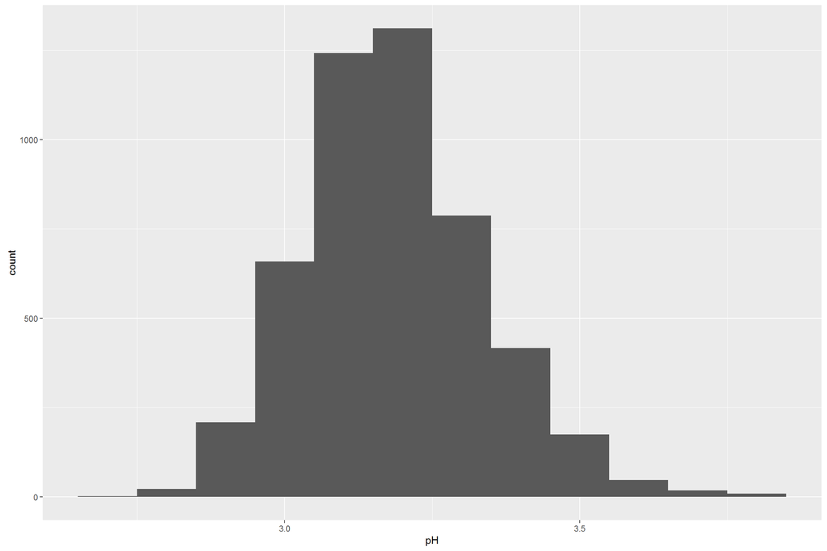

```
##    Min. 1st Qu.  Median    Mean 3rd Qu.    Max.
##   2.720   3.090   3.180   3.188   3.280   3.820
```

the distribution of wine in Ph was symmetry. mean ph is 3.188 , median is 3.18.

### sulphates

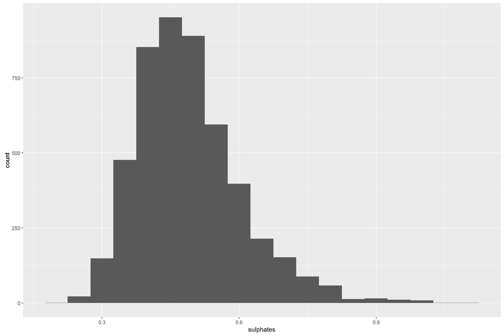

```
##    Min. 1st Qu.  Median    Mean 3rd Qu.    Max.
##  0.2200  0.4100  0.4700  0.4898  0.5500  1.0800
```

the distribution of wine in sulphates was slightly right skewed. mean content is 0.4898, median is 0.47 .

### alcohol

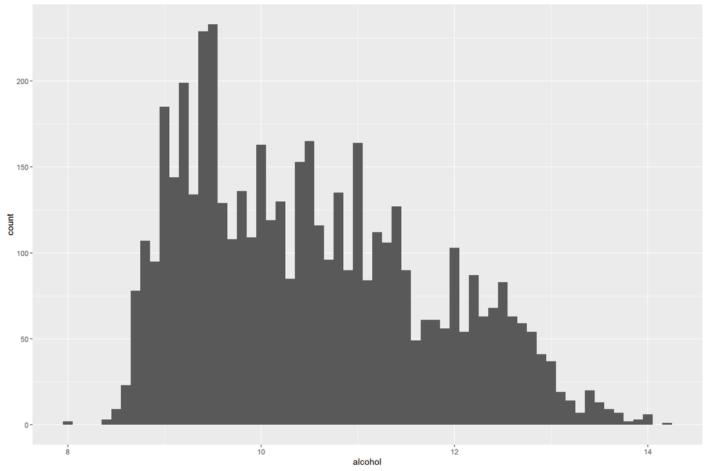

```
##    Min. 1st Qu.  Median    Mean 3rd Qu.    Max.
##    8.00    9.50   10.40   10.51   11.40   14.20
```

## 2 correlation matrix

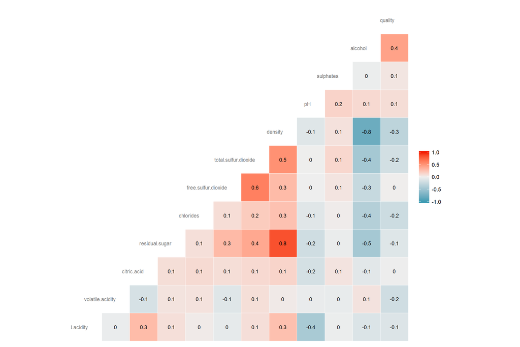

- we find these variable have relatively higher correlation :
1. alcohol
2. density
3. volatile.acidity
4. chlorides
5. total.sulfur.dioxide
- I want to know how these variables influence quality

## 3 Bivariate Analysis

#### alcohol Vs quanlity

look at alcohol distribute in wine with different quality

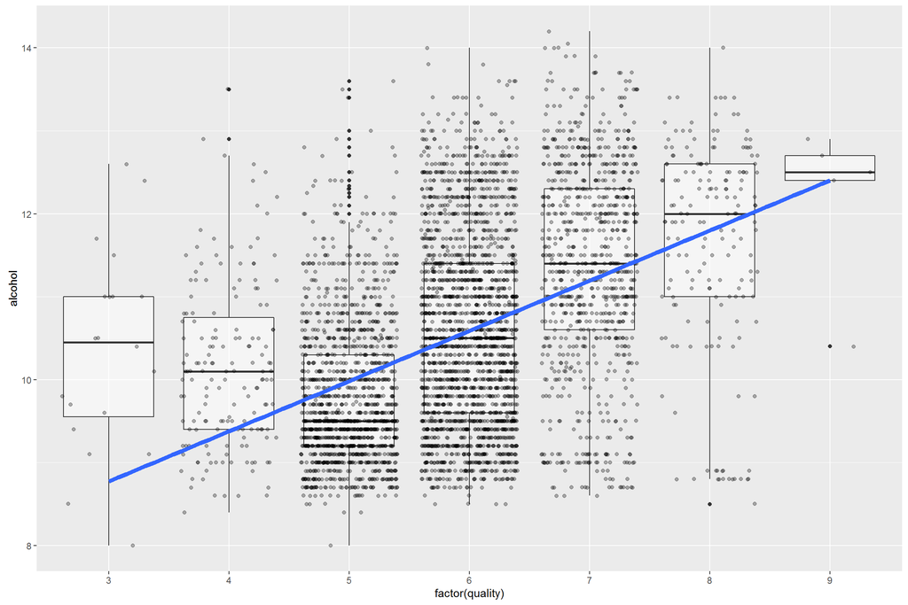

```
##               Df Sum Sq Mean Sq F value Pr(>F)
## alcohol        1  728.7   728.7    1146 <2e-16 ***
## Residuals   4896 3112.3     0.6
## ---
## Signif. codes:  0 '***' 0.001 '**' 0.01 '*' 0.05 '.' 0.1 ' ' 1
```

quality in 5~9, better wine tend to have higher content of alcohol.

One Way Anova show that , alcohol content do have significantly influence on quality rating.

#### density and quanlity

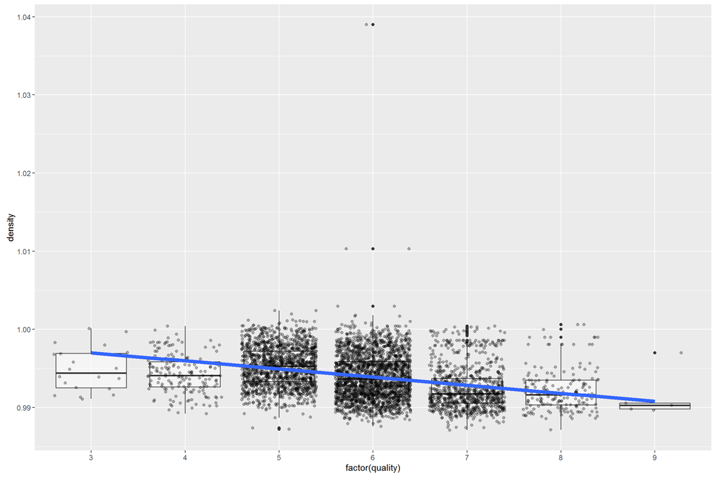

```
##               Df Sum Sq Mean Sq F value Pr(>F)
## density        1    362   362.3   509.9 <2e-16 ***
## Residuals   4896   3479     0.7
## ---
## Signif. codes:  0 '***' 0.001 '**' 0.01 '*' 0.05 '.' 0.1 ' ' 1
```

lower density winer tender to have higher quality.

One Way Anova show that : density have significantly influence on wine quanlity

#### volatile.acidity and quanlity

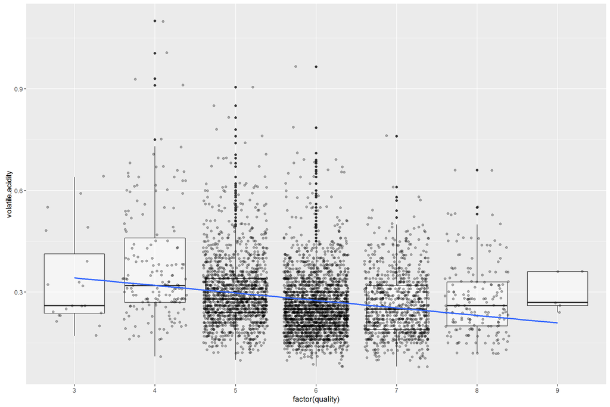

```
##                    Df Sum Sq Mean Sq F value Pr(>F)
## volatile.acidity    1    146  145.64     193 <2e-16 ***
## Residuals        4896   3695    0.75
## ---
## Signif. codes:  0 '***' 0.001 '**' 0.01 '*' 0.05 '.' 0.1 ' ' 1
```

as volatile.acidity increasing , quality have a slight decreasing trend.

ANOVA show the influence is significant

#### chlorides and quanlity

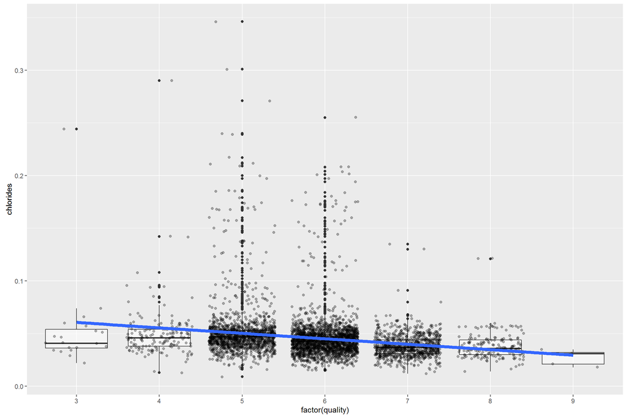

```
##               Df Sum Sq Mean Sq F value Pr(>F)
## chlorides      1    169  169.28   225.7 <2e-16 ***
## Residuals   4896   3672    0.75
## ---
## Signif. codes:  0 '***' 0.001 '**' 0.01 '*' 0.05 '.' 0.1 ' ' 1
```

higher quality tender to have lower chlorides.

ANOVA show the chlorides’s influence on quality is significant

#### total.sulfur.dioxide and quanlity

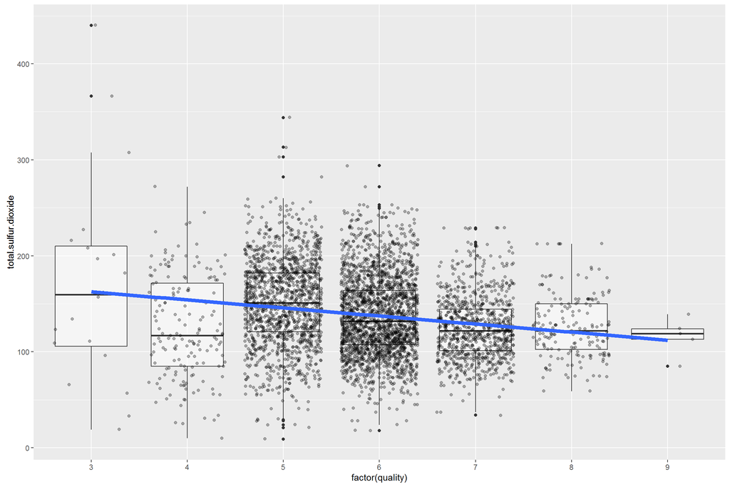

```
##                        Df Sum Sq Mean Sq F value Pr(>F)
## total.sulfur.dioxide    1    117  117.28   154.2 <2e-16 ***
## Residuals            4896   3724    0.76
## ---
## Signif. codes:  0 '***' 0.001 '**' 0.01 '*' 0.05 '.' 0.1 ' ' 1
```

higher quality wine tender to have lower chlorides total.sulfur.dioxide.

ANOVA also show the influence is significant

## 4 Multivariate Plots Section

### quality Vs alcohol and density

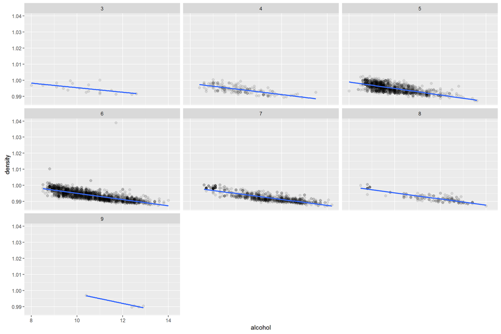

```
##   quality       corr
## 1       3 -0.6135293
## 2       4 -0.7029888
## 3       5 -0.6763350
## 4       6 -0.7435118
## 5       7 -0.8376100
## 6       8 -0.8755911
## 7       9 -0.9690080
```

from the plot we can see , higher quality(such as 7~9 ) wine more likely to appear on high acohol low density area .

higher qualiyt wines’ correlation between alcohol and density appear to be more close to -1 , indicate that high quality wine must have less chemical ingredient that may influen density other than alcohol.

### quality Vs chlorides and total.sulfur.dioxide

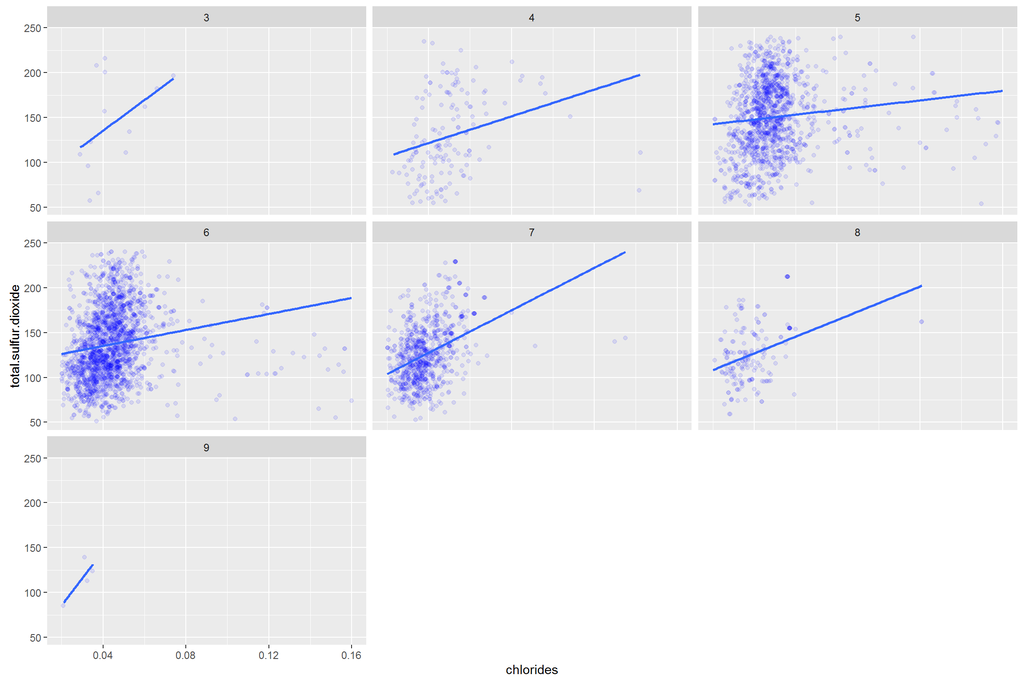

```
##   quality      corr
## 1       3 0.2421553
## 2       4 0.2831409
## 3       5 0.1247548
## 4       6 0.1342281
## 5       7 0.3989072
## 6       8 0.3263828
## 7       9 0.5087477
```

low quality wines’ chlorides and total.sulfur.dioxide have a wide distribution; higher quality wines’ chlorides and total.sulfur.dioxide more focused on both low area.

correlation’s differ betwwen different quality groups do not show something valuable.

## 5 Building the Linear Model

```
##
## Calls:
## m1: lm(formula = I(quality ~ alcohol), data = wqw)
## m2: lm(formula = quality ~ alcohol + density, data = wqw)
## m3: lm(formula = quality ~ alcohol + density + volatile.acidity,
##     data = wqw)
## m4: lm(formula = quality ~ alcohol + density + volatile.acidity +
##     chlorides, data = wqw)
## m5: lm(formula = quality ~ alcohol + density + volatile.acidity +
##     chlorides + total.sulfur.dioxide, data = wqw)
##
## ===================================================================================
##                            m1          m2          m3          m4          m5
## -----------------------------------------------------------------------------------
##   (Intercept)            2.582***  -22.492***  -36.499***  -35.573***  -30.759***
##                         (0.098)     (6.165)     (6.001)     (6.010)     (6.295)
##   alcohol                0.313***    0.360***    0.399***    0.389***    0.391***
##                         (0.009)     (0.015)     (0.014)     (0.015)     (0.015)
##   density                           24.728***   38.992***   38.217***   33.251***
##                                     (6.079)     (5.920)     (5.926)     (6.234)
##   volatile.acidity                              -2.072***   -2.043***   -2.070***
##                                                 (0.110)     (0.111)     (0.111)
##   chlorides                                                 -1.300*     -1.370*
##                                                             (0.542)     (0.543)
##   total.sulfur.dioxide                                                   0.001*
##                                                                         (0.000)
## -----------------------------------------------------------------------------------
##   R-squared                  0.2        0.2         0.2         0.2         0.2
##   adj. R-squared             0.2        0.2         0.2         0.2         0.2
##   sigma                      0.8        0.8         0.8         0.8         0.8
##   F                       1146.4      583.3       534.8       403.0       324.0
##   p                          0.0        0.0         0.0         0.0         0.0
##   Log-likelihood         -5839.4    -5831.1     -5660.2     -5657.3     -5654.0
##   Deviance                3112.3     3101.8      2892.6      2889.2      2885.4
##   AIC                    11684.8    11670.3     11330.3     11326.6     11322.1
##   BIC                    11704.3    11696.2     11362.8     11365.6     11367.5
##   N                       4898       4898        4898        4898        4898
## ===================================================================================
```

#### test our model

```
## [1] TRUE
```

## Final Plots and Summary

### plot 1

Previous research find out that the distribution of wine in alcohol was multimodal. I want to take a close look at its distribution

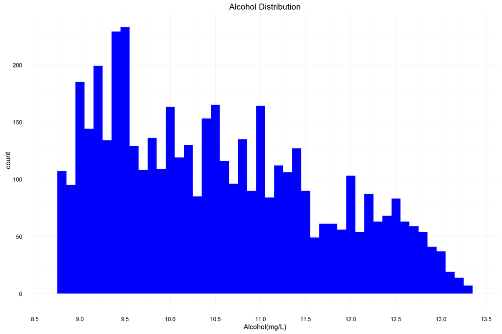

```
##
##   (8.5,9]   (9,9.5]  (9.5,10] (10,10.5] (10.5,11] (11,11.5] (11.5,12]
##       488       934       649       650       602       520       330
## (12,12.5] (12.5,13] (13,13.5]
##       356       253        73
```

### Description 1

The distribution of alcolhol appears to be multimodal

from the summary , we can see there are 3 distribution peak at alcohol level about 9.5,10.5,12,5 mg/L , it seem that there may be 3 main kinds of wine (high alcohol,low alcohol,mid alcohol)

### plot 2

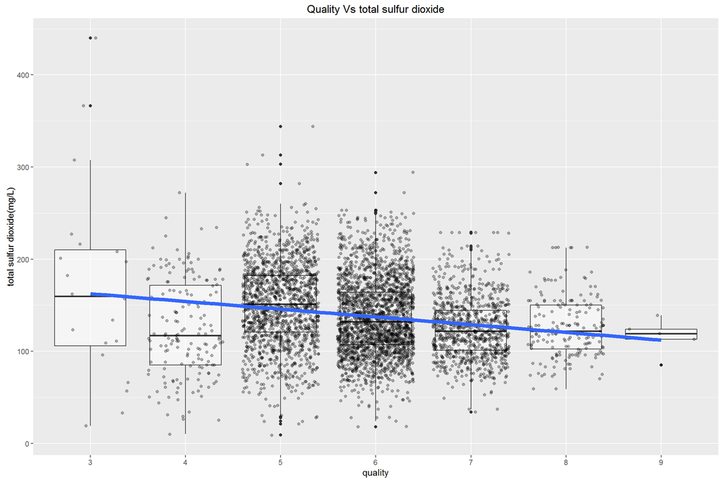

```
##   quality     mean median
## 1       3 170.6000  159.5
## 2       4 125.2791  117.0
## 3       5 150.9046  151.0
## 4       6 137.0473  132.0
## 5       7 125.1148  122.0
## 6       8 126.1657  122.0
## 7       9 116.0000  119.0
```

as we can see in the plot , there is a tender that high quality wine have low content of sulfur dioxide.it can be justified by the mean and median of sulfur dioxide was lower in higher quality wine.

### plot 3

so I want to know how the relationship between density and alcohol influence wine quality

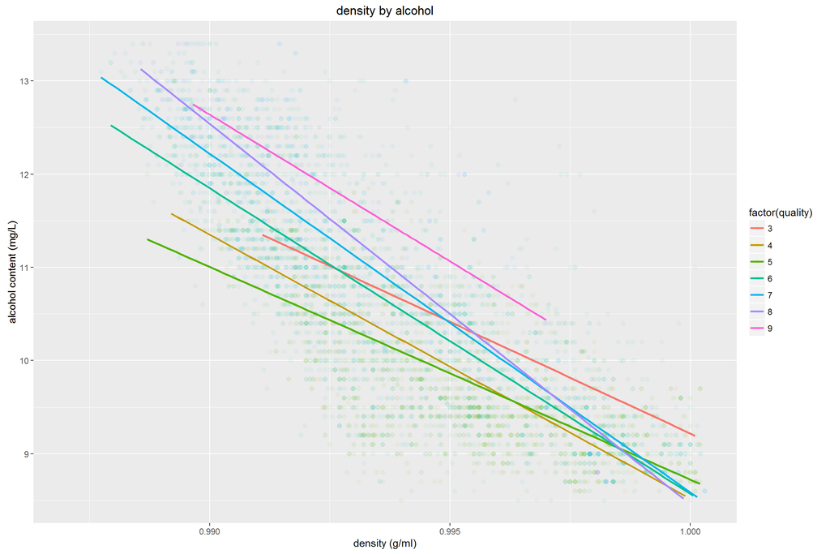

```
##   quality cor_alcohol_density
## 1       3          -0.6135293
## 2       4          -0.7029888
## 3       5          -0.6763350
## 4       6          -0.7435118
## 5       7          -0.8376100
## 6       8          -0.8755911
## 7       9          -0.9690080
```

### Description 3

higher quality wines’ correlation between alcohol and density appear to be more close to -1 , indicate that high quality wine must have less chemical ingredient that may influen density other than alcohol.

## Reflection

1. my vocabulary is very poor ,it take time to find proper word to discribe
2. Quality level is int make it more like categorical variable , make it more diffcult to plot.
3. I am a total beginner in R .so it take me a lot of time to fix bugs
4. future work : after I learn about logistic regression ,I can creat a better model.